# Julian Acevedo

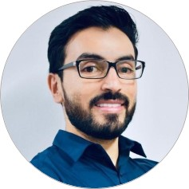

## Sobre mi

Estudiante de Maestría en Estadística Aplicada, Especialista en Estadística Aplicada y profesional en Ingeniería de Sistemas con más de 15 años de experiencia en Workforce Management (WFM) y Análisis de Datos en el sector BPO y BPM. Mi experiencia se centra en la capacidad de identificar y abordar desafíos empresariales a través del análisis de datos, potenciando la toma de decisiones estratégicas y operativas.

A lo largo de mi carrera, he desarrollado una sólida habilidad para automatizar y optimizar procesos, lo que ha resultado en mejoras significativas en la eficiencia y efectividad operativa. Mi capacidad para liderar equipos multidisciplinarios y trabajar de manera colaborativa ha sido clave en la implementación exitosa de proyectos de Business Intelligence y Data Science.

## Experiencia Profesional

### ATLANTIC QUANTUM INNOVATIONS

#### GERENTE EN CIENCIA DE DATOS

##### Estrategia de Datos y Gobernanza:

- Desarrollar y ejecutar la estrategia de datos de la empresa para asegurar que los datos sean una ventaja competitiva.
- Implementar políticas de gobernanza de datos para garantizar la integridad, privacidad y seguridad de los datos.
- Establecer y mantener estándares de calidad de datos y asegurar el cumplimiento de las regulaciones y normativas pertinentes.

##### Implementación y Supervisión de Business Intelligence:

- Liderar la creación y mantenimiento de una infraestructura de BI robusta que permita la toma de decisiones basada en datos.
- Supervisar el desarrollo de dashboards, informes y herramientas analíticas que proporcionen insights accionables a diferentes niveles de la organización.
- Colaborar con diferentes departamentos para identificar necesidades de BI y asegurar que las soluciones desarrolladas sean relevantes y útiles.

##### Liderazgo en Data Science:

- Dirigir equipos de científicos de datos en la creación de modelos predictivos, análisis avanzados y algoritmos de machine learning que optimicen operaciones y mejoren la experiencia del cliente.
- Facilitar la experimentación y la innovación en análisis de datos para descubrir nuevas oportunidades de negocio.
- Asegurar que los resultados de los modelos de data science se integren eficazmente en los procesos de negocio.

## Educación

### Actual:

MAESTRIA EN ESTADISTICA APLICADA / UNIVERSIDAD DEL NORTE

### 2021:

ESPECIALISTA EN ESTADISTICA APLICADA / UNIVERSIDAD DEL ATLANTICO

### 2012:

INGENIERO DE SISTEMAS / FUNDACIÓN UNIVERSITARIA SAN MARTIN